# ANLY_699_Assignment5

Subhash Pemmaraju

July 12, 2020

### Variables for Cluster Analysis

```r
clust_data <- merged_data[, c(10:27)]
clust_data1 <- clust_data[complete.cases(clust_data),]
#dim(fa_data1)
str(clust_data1)
```

```
## 'data.frame':    3120 obs. of  18 variables:
##  $ perc_fair_poor_health: int  21 18 30 19 22 31 28 23 24 21 ...
##  $ avg_phy_unh_days     : num  4.7 4.2 5.4 4.6 4.9 5.4 5.4 4.9 4.9 4.8 ...
##  $ avg_mental_unh_days  : num  4.7 4.3 5.2 4.6 4.9 4.9 5.3 4.8 4.9 4.7 ...
##  $ perc_smokers         : int  18 17 22 19 19 23 22 21 19 17 ...
##  $ perc_obese           : int  33 31 42 38 34 37 43 39 40 35 ...
##  $ food_env_ind         : num  7.2 8 5.6 7.8 8.4 4.3 6.6 6.9 6.4 8.3 ...
##  $ perc_phy_inact       : int  35 27 24 34 30 25 40 32 30 31 ...
##  $ perc_excess_drink    : num  15 18 12.8 15.6 14.2 ...
##  $ perc_uninsured       : int  9 11 12 10 13 11 11 12 12 11 ...
##  $ perc_college         : int  62 67 35 44 53 35 42 59 48 52 ...
##  $ perc_unemp           : num  3.6 3.6 5.2 4 3.5 4.7 4.8 4.7 3.9 3.6 ...
##  $ perc_child_pov       : int  19 14 44 28 18 68 36 27 31 25 ...
##  $ perc_diabetes        : int  11 11 18 15 17 24 19 18 20 15 ...
##  $ median_income        : int  59338 57588 34382 46064 50412 29267 37365 45400 39917 42132 ...
##  $ perc_65up            : num  15.6 20.4 19.4 16.5 18.2 16.4 20.3 17.7 19.5 23 ...
##  $ perc_black           : num  19.3 8.8 48 21.1 1.5 69.5 44.6 20.9 39.6 4.2 ...
##  $ perc_female          : num  51.4 51.5 47.2 46.8 50.7 45.5 53.4 51.9 52.1 50.5 ...
##  $ perc_18less          : num  23.7 21.6 20.9 20.5 23.2 21.1 22.2 21.6 20.8 19.2 ...
```

```r
#names(fa_data1)
```

The 18 variables above are used to identify clusters. The categories of the variables are broadly in 3 categories:

- Demographic Data (Age, Race, Gender)
- Socio-economic Data (Education, income, unemployment, insurane coverage, poverty etc.)
- Health Data (Obesity, Smoking, physical activity, mental health, drinking etc.)

### Optimal number of clusters and K-Means Clustering

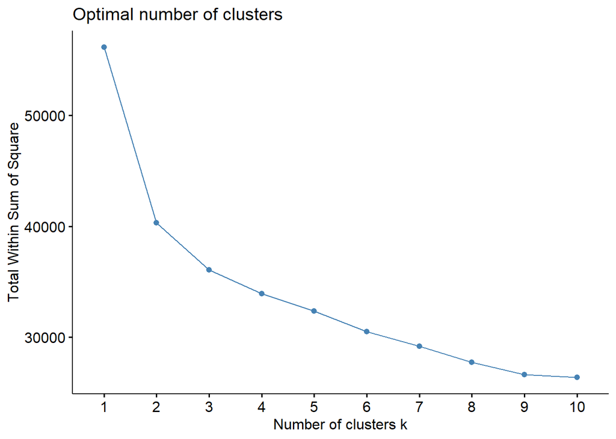

```r
df<-scale(clust_data1)

set.seed(123)

# function to compute total within-cluster sum of square

fviz_nbclust(df, kmeans, method="wss")
```

Based on the elbow plot, we can see that the bend in the elbow occurs at 3 clusters. Therefore, optimal number of clusters = 3. We also plot a range of cluster plots.

### K means cluster plots

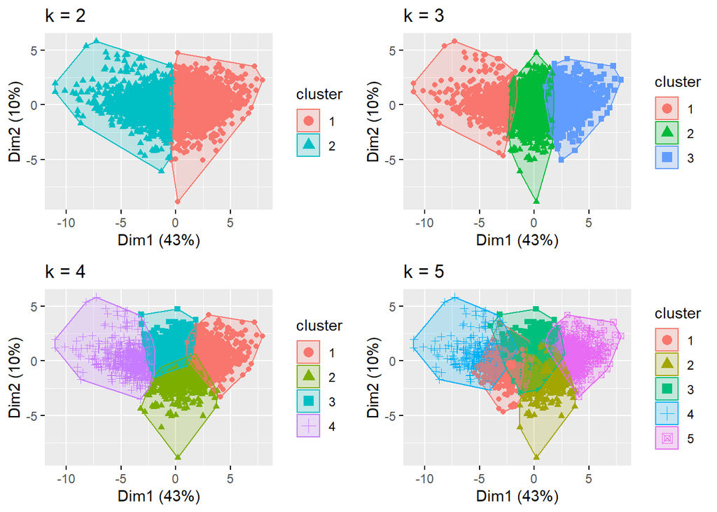

```r
k2 <- kmeans(df, centers = 2, nstart = 25)
k3 <- kmeans(df, centers = 3, nstart = 25)
k4 <- kmeans(df, centers = 4, nstart = 25)
k5 <- kmeans(df, centers = 5, nstart = 25)

# plots to compare
p1 <- fviz_cluster(k2, geom = "point", data = df) + ggtitle("k = 2")
p2 <- fviz_cluster(k3, geom = "point",  data = df) + ggtitle("k = 3")
p3 <- fviz_cluster(k4, geom = "point",  data = df) + ggtitle("k = 4")
p4 <- fviz_cluster(k5, geom = "point",  data = df) + ggtitle("k = 5")

library(gridExtra)
grid.arrange(p1, p2, p3, p4, nrow = 2)
```

```r
# Compute k-means clustering with k = 4
set.seed(123)
final <- kmeans(df, 3, nstart = 25)
print(final$centers)
```

```
##   perc_fair_poor_health avg_phy_unh_days avg_mental_unh_days perc_smokers
## 1           -0.92989169      -0.95904340          -0.9291810  -0.77697241
## 2            1.31418986       1.25994498           1.1231680   1.17792691
## 3            0.03208322       0.08324124           0.1319055  -0.01515278
##    perc_obese food_env_ind perc_phy_inact perc_excess_drink perc_uninsured
## 1 -0.52949167   0.62335994    -0.72647152        0.81573070     -0.5608488
## 2  0.74804259  -0.87444631     0.95114208       -1.02001347      0.3427638
## 3  0.01841211  -0.02493893     0.06476852       -0.09794453      0.2557387
##   perc_college    perc_unemp perc_child_pov perc_diabetes median_income
## 1    0.8746322 -0.5423748512    -0.90382624   -0.65413900     0.8861153
## 2   -0.8990331  0.8007697181     1.25782305    0.91006045    -0.9576412
## 3   -0.2072887  0.0007178443     0.04144577    0.03014415    -0.1854162
##     perc_65up perc_black perc_female  perc_18less
## 1 -0.10153935 -0.3622087 -0.01467851  0.004262794
## 2 -0.09262455  0.8785237  0.14545539  0.122109812
## 3  0.12757905 -0.1801499 -0.06502418 -0.067476685
```

```r
print(final$size)
```

```
## [1] 1053  712 1355
```

### Hierarchical Clustering

We use Agnes to conduct agglomeration clustering and identify which method has the highest coefficient. As can be seen below, that is the Ward method.

```r
# methods to assess
m <- c( "average", "single", "complete", "ward")
names(m) <- c( "average", "single", "complete", "ward")

# function to compute coefficient
ac <- function(x) {
  agnes(df, method = x)$ac
}

map_dbl(m, ac)
```

```
##   average    single  complete      ward
## 0.8478885 0.7031994 0.9049859 0.9882121
```

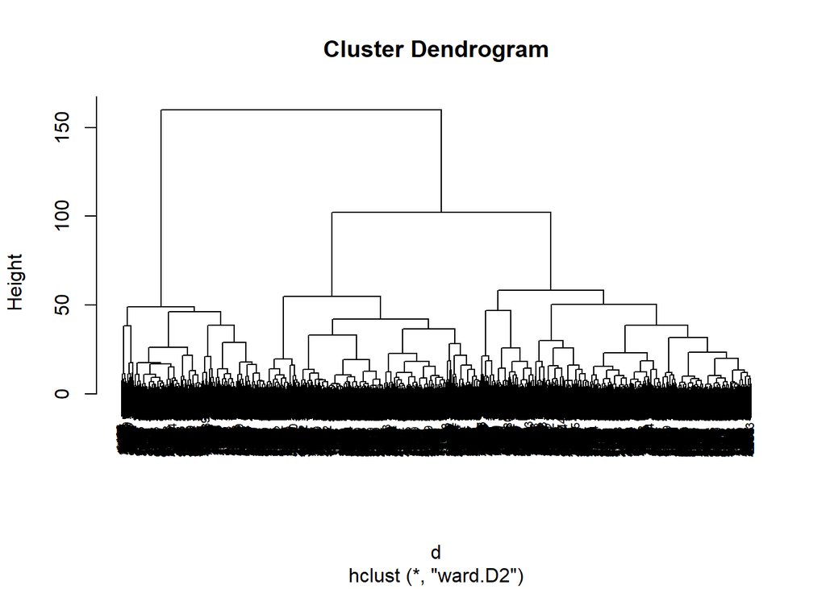

```r
# Dissimilarity matrix
d <- dist(df, method = "euclidean")

# Ward's method
hc3 <- hclust(d, method = "ward.D2" )

plot(hc3, cex = 0.6)
```

From the dendrogram, we can see that the number of optimal clusters is again 3, similar to K-means clustering.

### Hierarchical clustering analysis

```r
# Cut tree into 4 groups
sub_grp <- cutree(hc3, k = 3)

# Number of members in each cluster
table(sub_grp)
```

```
## sub_grp
##    1    2    3
## 1338  718 1064
```

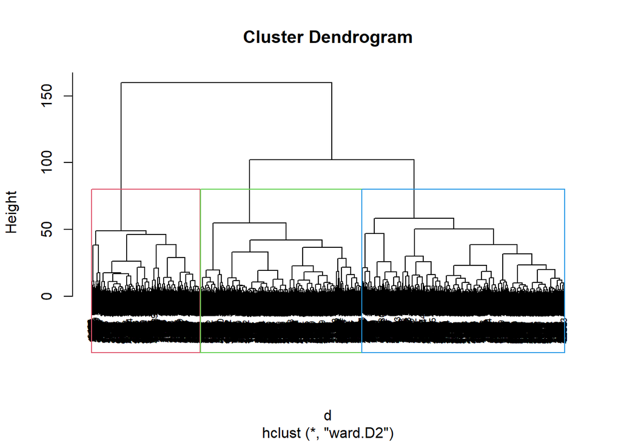

```r
plot(hc3, cex = 0.6)
rect.hclust(hc3, k = 3, border = 2:5)
```

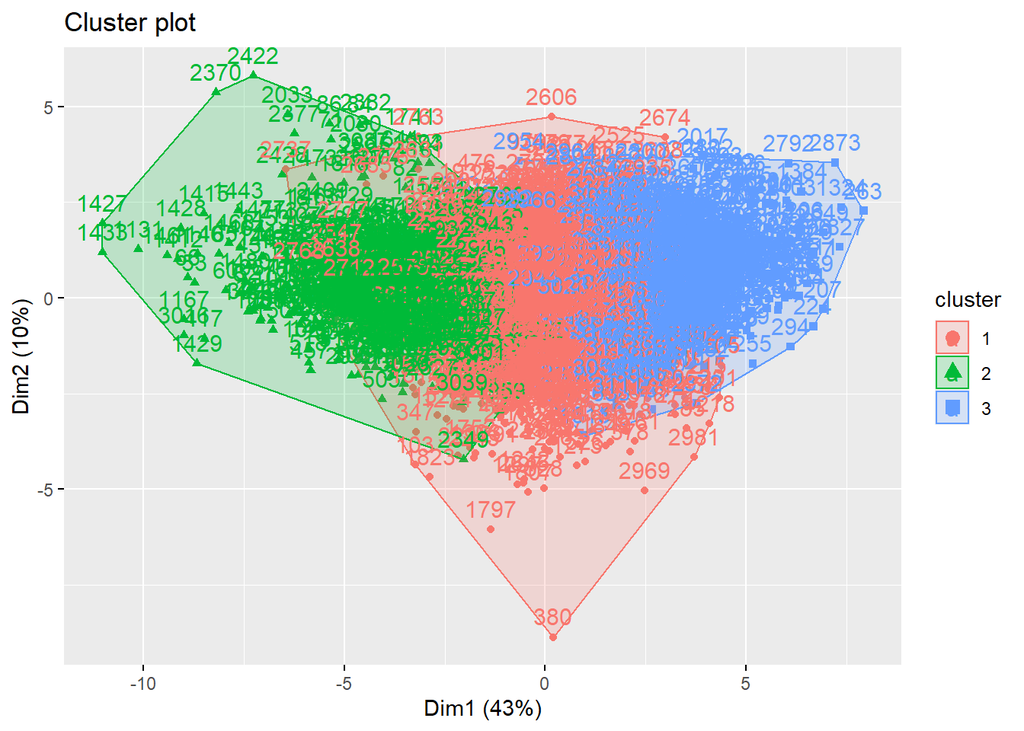

```r
fviz_cluster(list(data = df, cluster = sub_grp))
```

Number of members in each cluster and the boundaries of each clusters are shown in the plot above.